# Kinetic segregation

Physics 230A/146A — Biological Physics

Jun Allard

## Surface molecules of different sizes

1998–2006 van der Merwe Lab, Davis Lab

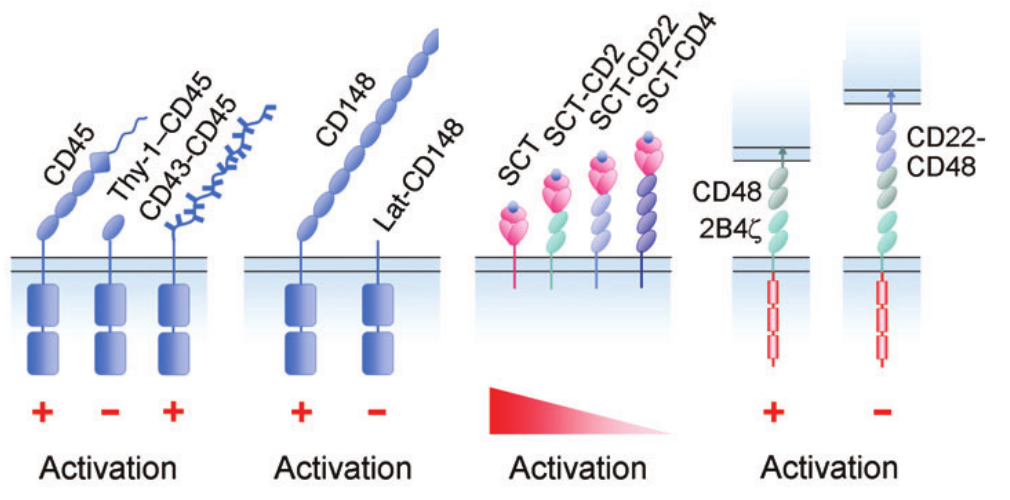

Davis & van der Merwe, *Nature Immunology* 2006

[figure not shown]

- Receptors and their ligands (e.g., TCR and pMHC “antigen”)
- Non-specific adhesion molecules (e.g., LFA1 integrin and ICAM)
- Large-ectodomain surface molecules (e.g., CD45)

## How tall is each one?

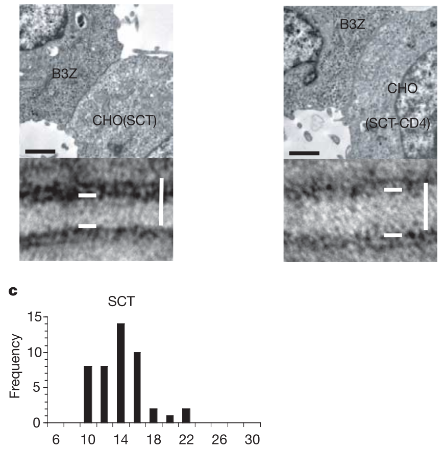

Choudhury … van der Merwe, *Nature* 2005

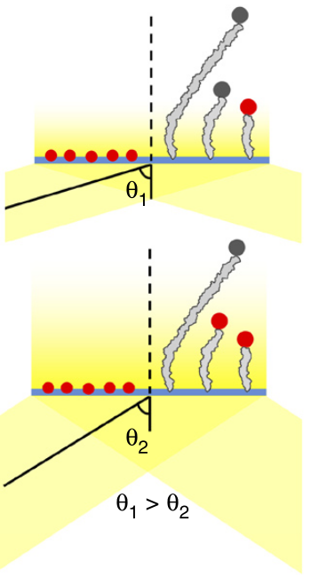

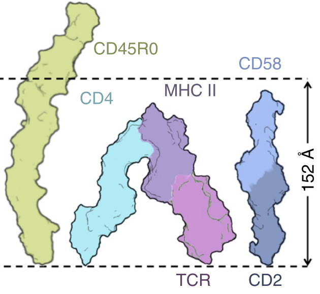

Using “variable-angle TIRF”, phosphatase (CD45R0) is **22.6 nm**.

Chang … Davis, *Nature Immunology* 2016

- Receptors and their ligands (e.g., TCR and pMHC “antigen”) ~ 13–15 nm?
- Non-specific adhesion molecules (e.g., LFA1 integrin and ICAM) ~ 27 nm?
- Large-ectodomain surface molecules (e.g., CD45) ~ 23 nm?

## The kinetic-segregation model

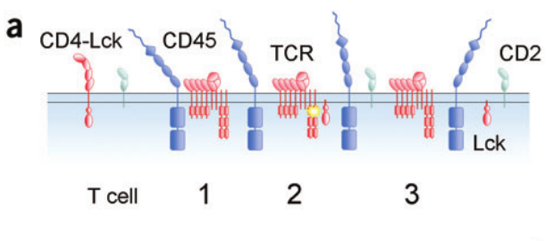

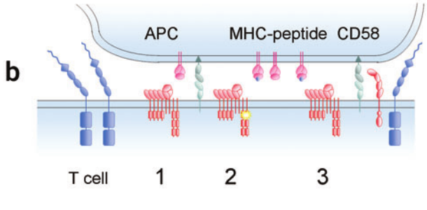

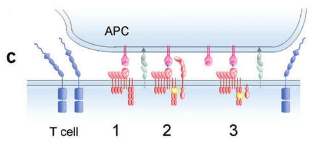

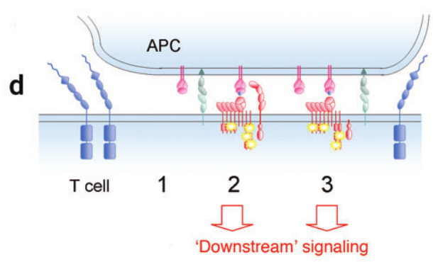

Davis & van der Merwe, *Nature Immunology* 2006

*The kinetic-segregation model: TCR triggering and beyond*

## Which receptor-ligand pairs exploit this?

There are many **non-catalytic** receptors whose ligands are attached to a **surface**.

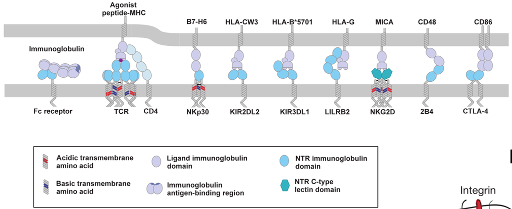

Dushek *et al.* (2012)

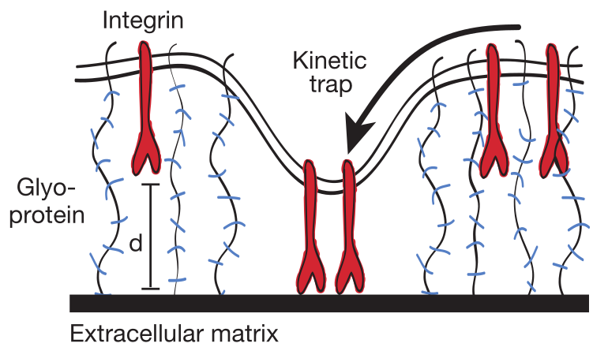

Paszek *et al.* (2014)

## Segregation at close contacts

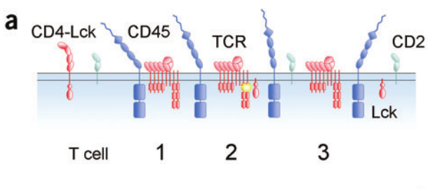

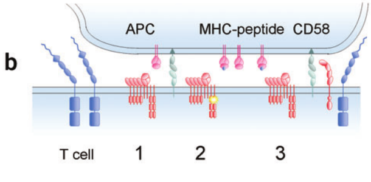

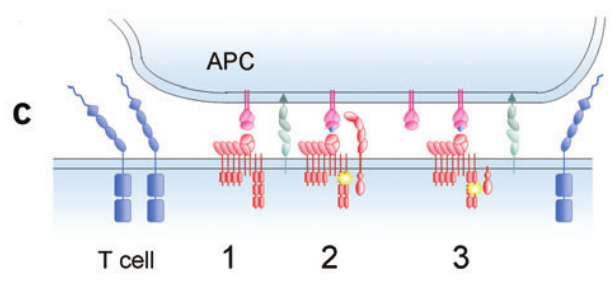

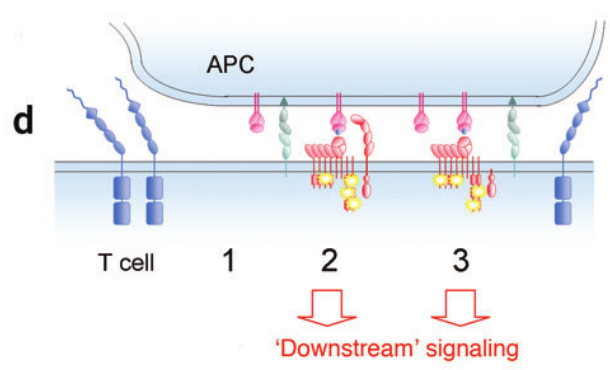

Davis & van der Merwe, *Nature Immunology* 2006

[figure not shown]

Chang *et al.*, *Nature Immunology* 2016

## 2016: Experimental observation of kinetic segregation

[figure not shown]

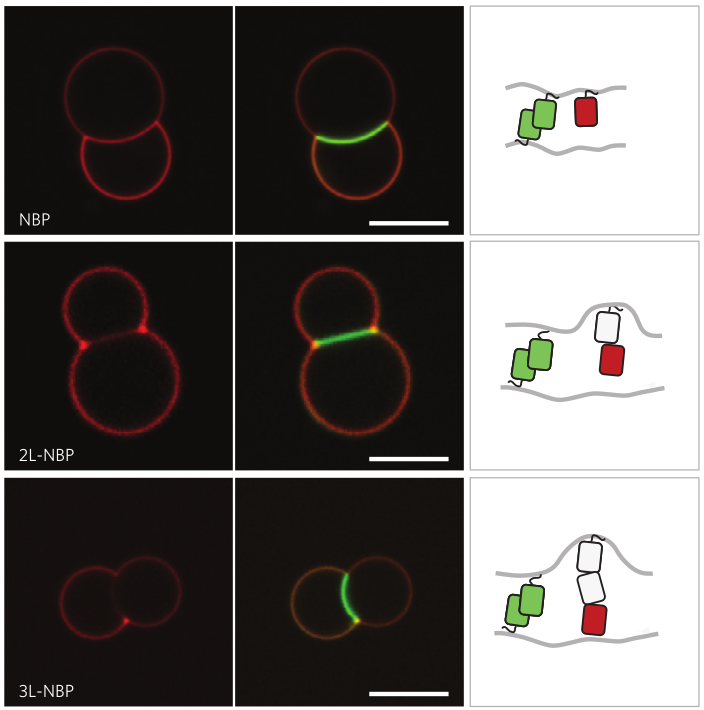

Schmid *et al.*, *Nature Physics* 2016

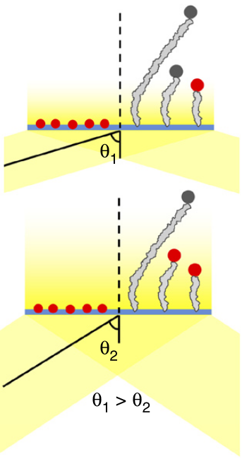

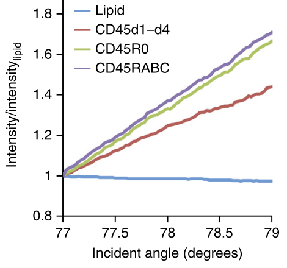

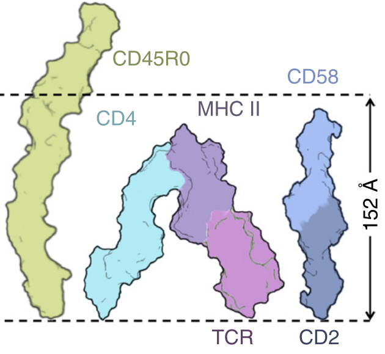

Using “variable-angle TIRF”, phosphatase (CD45R0) is **22.6 nm**.

Chang *et al.* *Nature Immunology*, May 2016